# Notebook

**Bayesian Iterated Learning Model**

# Julia

```python
# has the power of Lisp, the aesthetics of Python and the speed of C:

macro time(ex)
    return quote
        local t0 = time()
        local val = $(esc(ex)) # esc assures hygiene
        local t1 = time()
        @printf "Took: %.3f seconds\n" t1 - t0 # C like string formatting
    end
end


for i in 1:10
    @time factorial(big(1000000))
end
```

```
Took: 0.405 seconds
Took: 0.418 seconds
Took: 0.401 seconds
Took: 0.392 seconds
Took: 0.391 seconds
Took: 0.394 seconds
Took: 0.393 seconds
Took: 0.411 seconds
Took: 0.405 seconds
Took: 0.392 seconds
```

[figure not shown]

```python
using Images

imread("files/open_source.jpg")
```

```python
repo = "https://github.com/dostodabsi/bayesian_ILM"

run(`xdg-open $repo`)
```

# Iterated Learning Models

Biological evolution provided us with ontogenetic constraints.

Cultural transmission and information bottlenecks additionally constrain language evolution.

[figure not shown]

# Bayesian Minds

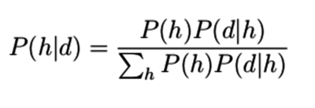

```python
imread("files/bayes_rule.png")
```

```python
d = [1 3 3] # example dataset

prior = [.5 .5] # prior probability of the hypotheses (before seeing any data)

h = [.2 .2 .6  # h1: P(d1) = P(d2) = .2, P(d3) = .6
     .3 .3 .4] # h2: P(d1) = P(d2) = .3, P(d3) = .4
;
```

```python
df = bayes(prior, h, d)
```

|  | data | prior | likelihood | posterior |
| --- | --- | --- | --- | --- |
| 1 | 133 | 0.5 | 0.072 | 0.6 |
| 2 | 133 | 0.5 | 0.048 | 0.4 |

# Learning Algorithms

```python
import Distributions:wsample

nr_hyp = 2
nr_data = 3
posterior = df[:posterior];
```

```python
# MAP
max_value = maximum(posterior)
max_pos = findin(posterior, max_value)
MAP = h[max_pos, :]
```

```
1x3 Array{Float64,2}:
 0.2  0.2  0.6
```

```python
# Sampling
sampling_pos = wsample(1:nr_hyp, collect(posterior), 1)
sampling = h[sampling_pos, :]
```

```
1x3 Array{Float64,2}:
 0.2  0.2  0.6
```

```python
# data generation
new_data = wsample(1:nr_data, collect(sampling), 3)'
```

```
1x3 Array{Int64,2}:
 2  3  2
```

# Markov Chains

Stochastic process whose present state $s_n$ does only depend on the preceeding $s_{n-1}$ but not on earlier states.

A state is expressed as a vector $S = (s_1, s_2)^T$. The transition from $S_n$ to $S_{n+1}$ is defined by the transition matrix $T$ which contains the transition probabilies for each of the elemts of $S_n$.

**Example**:

[figure not shown]

Consider two possible languages, $E$ and $A$. In each step the probability to change from $E$ to $A$ is 0.7 and to stay with $E$ is 0.3 and so on. This gives the transition matrix $T = \begin{pmatrix} 0.3 & 0.4 \\ 0.7 & 0.6 \end{pmatrix}$. For a given initial condition $S_0$ of the distribution of the languages $E$ and $A$ in a population the state $S_1$ is simply given by $T \cdot S_0$. The distribution in the $n$th generation equal to $T^n \cdot S_0$.

$S_0 = \begin{pmatrix} 0.9 \\ 0.1 \end{pmatrix}$ $\Rightarrow T \cdot S_0 = \begin{pmatrix} 0.31 \\ 0.69 \end{pmatrix} \Rightarrow T \cdot \begin{pmatrix} 0.31 \\ 0.69 \end{pmatrix} = \begin{pmatrix} 0.369 \\ 0.631 \end{pmatrix}$ ...

# Simulation I: Early Work

*Deriving the transition matrix for sampling over the posterior for a two language simulation*

$Q = \begin{pmatrix} q_{11} & q_{12} \\ q_{21} & q_{22} \end{pmatrix} = \begin{pmatrix} 1-q_{21} & q_{12} \\ q_{21} & 1-q_{12} \end{pmatrix}$

*### The production algorithm PA*

Production of an $(x,y)$ pair involves two stages

1. sampling an x according to $P(x)$
2. producing an utterance $y$ appropriate to $x$ according to PA

   $P_{PA}(d=(x,y)|h=i)=\begin{cases}P(x)(1-\epsilon) & \text{if y maps to $x$ in $h_i$} \\ P(x)\epsilon & \mathrm{otherwise}\end{cases}$

*### Using Bayes rule to derive the posterior*

$P(h|d) = \frac{P_{PA}(d|h)P(h)}{\sum_{h\in H}P(d|h)P(h)}$

Let $\alpha = P(h_1)$, the prior.

Given a certain $(x,y)$ pair, according to PA, there are three cases, $(x,y)$ can be the result of.

[figure not shown]

1. $x$ belongs to the subset $S$ of utterances for which each $h$ produces the same $y$ $\Rightarrow \frac{(1-\epsilon)\alpha}{(1-\epsilon)\alpha + (1-\epsilon)(1-\alpha)} = \alpha$
2. $x$ belongs to the subset $G_1$ for which only $h_1$ produces $y$ $\Rightarrow \frac{(1-\epsilon)\alpha}{(1-\epsilon)\alpha + \epsilon(1-\alpha)}$
3. $x$ belongs to the subset $G_2$ for which only $h_2$ produces $y$ $\Rightarrow \frac{\epsilon\alpha}{\epsilon\alpha + (1-\epsilon)(1-\alpha)}$

*### Determinig $q_{12}$ and $q_{21}$*

$q_{12}$ detemines the portion of $h_2$ that switches to $h_1$ and $q_{21}$ the other way around. Thus , for the sampling algorithm, the values are the sums over the three cases, weighted with the respective probability that a observed $(x,y)$ pair belongs to one of the cases.

1. $s = \sum_{x \in S}P(x)$
2. $(1-s)(1-\epsilon)$ if $h_{n-1}$ was $h_1$; $(1-s)\epsilon$ if $h_{n-1}$ was $h_2$
3. $(1-s)\epsilon$ if $h_{n-1}$ was $h_1$; $(1-s)(1-\epsilon)$ if $h_{n-1}$ was $h_2$

thus $q_{12} = s\alpha + \frac{(1-\epsilon)\alpha}{(1-\epsilon)\alpha + \epsilon(1-\alpha)}(1-s)\epsilon + \frac{\epsilon\alpha}{\epsilon\alpha + (1-\epsilon)(1-s)}(1-\epsilon)(1-\epsilon)$

since $q_{21}$ is the reverse process, it simply derived by interchaniging the $\alpha$ and $1-\alpha$.

```python
function simulate(α, ϵ; n=10, s=.5, MAP=false)
    # α ~ prior; ϵ ~ noise
    # s ~ probability for both languages producing the same y

    if MAP
        R(x) = x == .5 ? .5 : x > .5 ? 1 : 0
        q_12 = s + (1 - s)*ϵ + R(ϵ*α / (ϵ*α + (1 - ϵ)*(1 - α))) * (1 - s)*(1 - ϵ)
        q_21 = R(ϵ*(1 - α) / (ϵ*(1 - α) + (1 - ϵ)*α)) * (1 - s)*(1 - ϵ)
    else
        q_12 = begin α*s +
            ((1 - ϵ)*α / ((1 - ϵ)*α + ϵ*(1 - α))) * (1 - s)*ϵ +
            (ϵ*α / (ϵ*α + (1 - ϵ)*(1 - α))) * (1 - s)*(1 - ϵ)
        end

        q_21 = begin (1 - α)*s +
            ((1 - ϵ)*(1 - α) / ((1 - α)*(1 - α) + ϵ*α)) * (1 - s)*ϵ +
            (ϵ*(1 - α) / (ϵ*(1 - α) + (1 - ϵ)*α)) * (1 - s)*(1 - ϵ)
        end
    end

    Q = [1-q_21 q_12
         q_21 1-q_12]

    inits = MAP ? [.5 .5] : [1 0]
    S = [inits; zeros(n, 2)]

    for i in 2:n+1
        S[i, :] = Q * S[i-1, :]'
    end

    return S
end;
```

```python
S1 = simulate(.6, .05);
S2 = simulate(.6, .001);
```

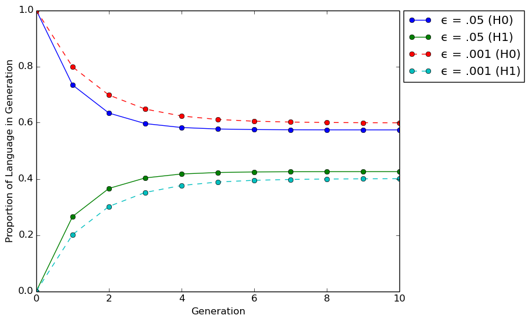

```python
using PyPlot

plot(S1, marker="o");
plot(S2, marker="o", linestyle="dashed");
legend(["ϵ = .05 (H0)", "ϵ = .05 (H1)", "ϵ = .001 (H0)", "ϵ = .001 (H1)"], bbox_to_anchor=(1.36, 1.02));
xlabel("Generation");
ylabel("Proportion of Language in Generation");
```

```python
S3 = simulate(.6, .001; s=.2, MAP=true);
S4 = simulate(.6, .001; s=.8, MAP=true);
```

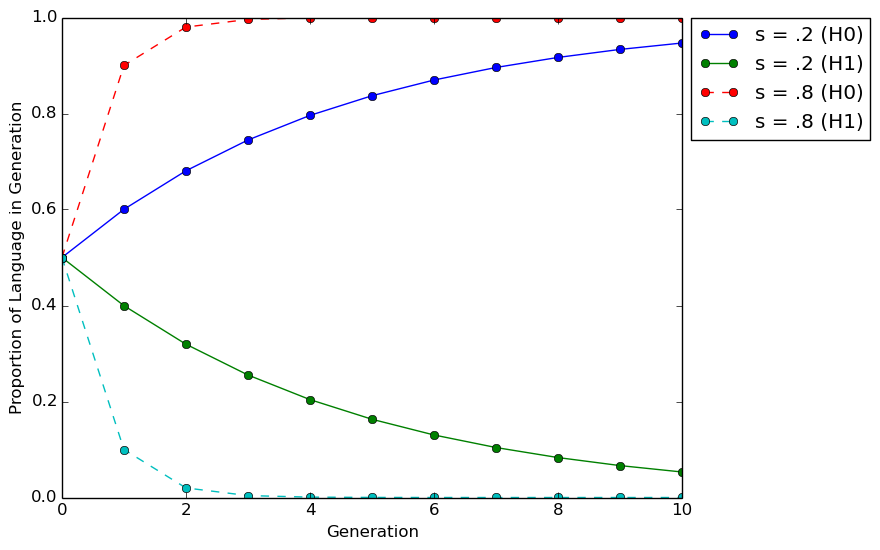

```python
plot(S3, marker="o");
plot(S4, marker="o", linestyle="dashed");
legend(["s = .2 (H0)", "s = .2 (H1)", "s = .8 (H0)", "s = .8 (H1)"], bbox_to_anchor=(1.32, 1.02));
xlabel("Generation");
ylabel("Proportion of Language in Generation");
```

- its asymptotic behavior should reflect the predominace of languages with high prior probabilities. That is the language with the highest prior survives.

# Simulation II: Extensions

```python
function simulate(;MAP=true, N_sam=1, N_gen=10000,
                   priors=[.8 .1 .1; .1 .1 .8], H=[.6 .2 .2; .2 .6 .2; .2 .2 .6])

    h_row, h_col = size(H)
    p_row, p_col = size(priors)
    @assert p_col == h_row

    N_pop = p_row # number of populations
    N_hyp = h_row # number of hypotheses
    N_dat = h_col # number of data points seen
    N_sampop = N_sam * N_pop # number of samples, agents per population

    # keep track of the history
    posterior_history = zeros(N_gen, N_pop, N_hyp)
    hypotheses_history = zeros(N_gen, N_pop)
    hyphist = zeros(N_pop, N_hyp)
    hyphistnorm = zeros(N_pop, N_hyp)

    posterior = zeros(N_pop, N_hyp)
    agents_posterior = zeros(N_pop, N_hyp)
    agents_hypothesis = zeros(N_pop, 1)

    # priors over hypotheses over populations
    priors = log(priors)

    # ~ likelihood of data points under each hypothesis
    hypotheses = log(H)

    # initial data matrix
    data = rand(1:N_dat, (1, N_sampop))

    # for each generation
    for generation in 1:N_gen

        # for each population
        for i in 1:N_pop
            likelihood = zeros(1, N_hyp) # reset the likelihood

            # for each sample per population per generation
            for j in 1:N_sampop
                likelihood += hypotheses[:, data[j]]' # hypotheses are the likelihoods
            end

            agents_posterior[i, :] = bayes_rule(priors[i, :], likelihood)
            posterior_history[generation, :, :] = agents_posterior

            if MAP
                ############################
                post = agents_posterior[i, :]
                value = maximum(post)
                pos = findin(post, value)
                s = size(pos)[1]

                # if there is more than one maximum, choose randomly between them
                if s > 1
                    pos = pos[rand(1:s, 1)]
                end

                agents_hypothesis[i, :] = pos[1]
                hypotheses_history[generation, i] = pos[1]
                ####################################
            else # Sampling
                ############################
                weights = agents_posterior[i, :]'
                agents_hypothesis[i] = wsample(1:N_hyp, collect(weights), N_sam)[1]
                hypotheses_history[generation, i] = agents_hypothesis[i]
                ####################################
            end
        end

        # generate data
        data = Int64[]
        for i in 1:N_pop
            weights = exp(hypotheses[agents_hypothesis[i], :])
            agent_data = wsample(1:N_dat, collect(weights), N_sam)
            append!(data, agent_data)
        end
    end

    # create hypotheses history
    for pop in 1:N_pop
        for h in 1:N_hyp
            for g in 1:N_gen
                if hypotheses_history[g, pop] == h
                    hyphist[pop, h] += 1
                end
            end
        end
    end

    for i in 1:N_pop
        hyphistnorm[i, :] = hyphist[i, :] ./ sum(hyphist[i, :])
    end

    return hyphistnorm
end;
```

# One agent population

```python
bottleneck = 3 # information bottleneck
prior = [.7 .2 .1] # 1 prior => 1 agent per population; 3 Elements => 3 data points
#prior = [1/3 1/3 1/3]
hypotheses = [.6 .2 .2; .2 .6 .2; .2 .2 .6];
```

```python
one_map = simulate(priors = prior, H = hypotheses, N_sam = bottleneck);
```

```python
one_sampling = simulate(MAP = false, priors = prior, H = hypotheses, N_sam = bottleneck);
```

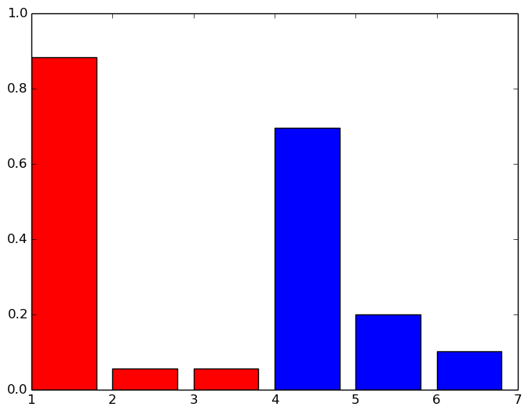

```python
plot_population([one_map one_sampling]');
```

# Changing the bottleneck

```python
b = [1:10]
prior = [1/3 1/3 1/3]
H = [.6 .2 .2; .2 .6 .2; .2 .2 .6]
# H = [.6 .3 .1; .2 .6 .2; .1 .3 .6]

bmap = simulate_bottlenecks(prior = prior, bottlenecks = b);
bsampling = simulate_bottlenecks(prior = prior, bottlenecks = b);
bmap_ncanonical = simulate_bottlenecks(prior = prior, bottlenecks = b, canonical = false);
```

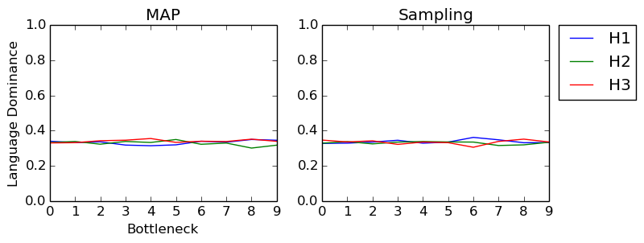

```python
plot_bottleneck(bmap, bsampling);
```

```python
b = [1:3:30]
prior = [.6 .3 .1]
H = [.6 .2 .2; .2 .6 .2; .2 .2 .6]

map = simulate_bottlenecks(prior = prior, bottlenecks = b)
sampling = simulate_bottlenecks(MAP = false, prior = prior, bottlenecks = b);
map_ncanonical = simulate_bottlenecks(canonical = false, prior = prior, bottlenecks = b);
```

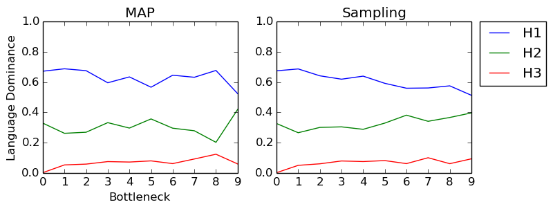

```python
plot_bottleneck(map, sampling);
```

# Multi-agents population

```python
agents = 4
prior = [.7 .2 .1];
```

```python
multi_map = simulate_population()
```

|  | one_agent | four_agents |
| --- | --- | --- |
| 1 | 0.668 | 0.649 |
| 2 | 0.215 | 0.224 |
| 3 | 0.117 | 0.127 |

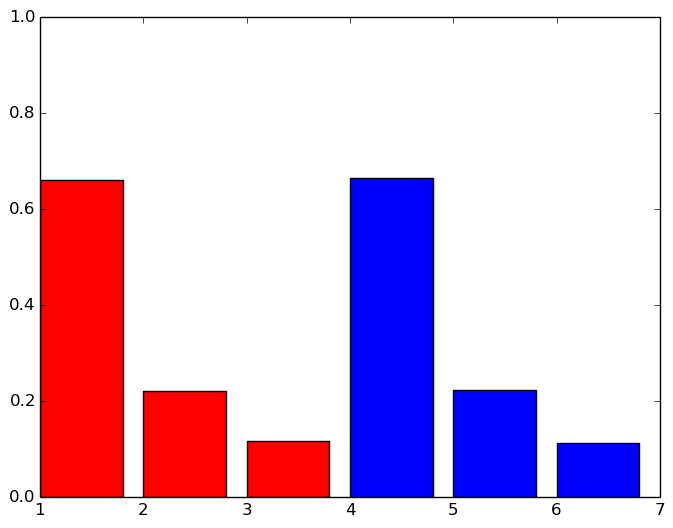

```python
plot_population([multi_map[:one_agent]; multi_map[:four_agents]]);
```

```python
multi_sampling = simulate_population(MAP = false)
```

|  | one_agent | four_agents |
| --- | --- | --- |
| 1 | 0.693 | 0.806 |
| 2 | 0.217 | 0.14 |
| 3 | 0.09 | 0.055 |

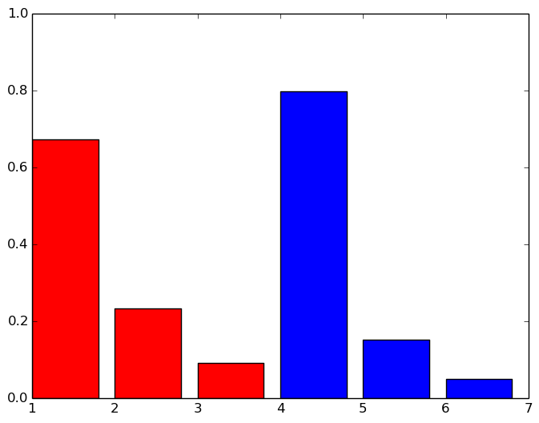

```python
plot_population([multi_sampling[:one_agent]; multi_sampling[:four_agents]]);
```

# Extensions

## Agents are not perfectly rational

## Make horizontal transmission more realistic

# Discussion

## How to best combine horizontal and vertical transmission?

[figure not shown]

#### --- Scott-Philips and Kirby (2010)

## Literature

Griffith, T. L. and Kalish, M. L. *Language Evolution by Iterated Learning With Bayesian Agents* in Cognitive Science, 31 (2007), 441–480

Ferdinand, V. and Zuidema, W. *Language adapting to the brain: a study of a Bayesian iterated learning model* http://citeseerx.ist.psu.edu/viewdoc/summary?doi=10.1.1.158.8692

```python
# motivate a research design
run(`xdg-open http://imsowwy.herokuapp.com/`)
```

# Helper Functions

```python
using DataFrames


function bayes(priors, hypotheses, data)
    llhs = mapslices(h -> *(h[d]...), hypotheses, 2) # P(d|h) for each h
    propto = llhs' .* priors # P(h) * P(d|h) for each h
    posterior = propto / sum(propto) # P(h|d) for each h
    DataFrame(data = rep(join(data), 2), prior = vec(prior),
         likelihood = vec(round(llhs, 4)), posterior = vec(round(posterior, 4)))
end;


function bayes_rule(prior, llh)
    posterior = exp(prior + llh)
    return posterior / sum(posterior)
end;

# simulate effect of bottleneck size
function simulate_bottlenecks(;MAP=true, canonical = true, bottlenecks=[1:10],
                               prior = [1/3 1/3 1/3])

    res = zeros(length(bottlenecks), 3)
    hypotheses = canonical ? [.6 .2 .2; .2 .6 .2; .2 .2 .6] :
                             [.6 .3 .1; .2 .6 .2; .1 .3 .6]

    for (i, b) in enumerate(bottlenecks)
        res[i, :] = simulate(priors = prior, H = hypotheses, N_sam = b)
    end

    return res
end

# compare effect of multiple {agents, samples} in a population
function simulate_population(;MAP = true, prior = [.7 .2 .1], agents = 4,
                              H = [.8 .1 .1; .1 .8 .1; .1 .1 .8])

    res = zeros(2, 3)
    bottleneck = agents
    multi_agent = vcat([prior for i in 1:agents]...)

    res[1, :] = simulate(priors = prior, H = H, N_sam = bottleneck, MAP = MAP)
    res[2, :] = mean(simulate(priors = multi_agent, H = H, MAP = MAP), 1)

    df = convert(DataFrame, round(res', 3))
    names!(df, [:one_agent, :four_agents])
    return df
end;


function plot_population(both)
    plt.bar([1:6], both, color = ["red", "red", "red", "blue", "blue", "blue"])
    plt.ylim([.0, 1]);
end

function plot_bottleneck(map, sampling)
    subplot(221);
    plot(map);
    plt.xlabel("Bottleneck");
    plt.ylabel("Language Dominance");
    plt.ylim([0, 1])
    title("MAP")

    subplot(222);
    plot(sampling);
    plt.legend(["H1", "H2", "H3"], bbox_to_anchor=(1.42, 1.048));
    plt.ylim([0, 1])
    title("Sampling")
end;
```